# Rmarkdown-starter

François Birgand

3/24/2022

The beauty of Markdown is to embed R codes, within the text, such that in the end, a document could contain all the text and code to create figures and tables, in *one document*. I have written a crash course on R Markdown, which you can find at [this link](https://francoisbirgand.github.io/tutorial-RMarkdown_instructions.html).

There are three components to an R Mardown document (.Rmd):

- YAML header
- Text
- Code chunks

After you are done reading [the crash course](https://francoisbirgand.github.io/tutorial-RMarkdown_instructions.html), you will want to be able to find a [reference summary of R markdown here](https://rstudio.com/wp-content/uploads/2016/03/rmarkdown-cheatsheet-2.0.pdf).

- YAML header: The header of the document starts with a YAML which acronym started as “Yet Another Markup Language” and now apparently stands for “YAML Ain’t Markup Language”… The YAML Header specifies how the document will be formatted.
- Text: most of your writing will be done using plain text, very much like you have been doing with Word, with mark-up alterations. Many details on mark-up are in [the crash course](https://francoisbirgand.github.io/tutorial-RMarkdown_instructions.html). Spell check can be done using
  - A spell check button to the right of the save button (with “ABC” and a check mark).
  - Edit > Check Spelling…
  - The F7 key
- Code Chunks: This is where you will add the actual R code that will create tables and figures.

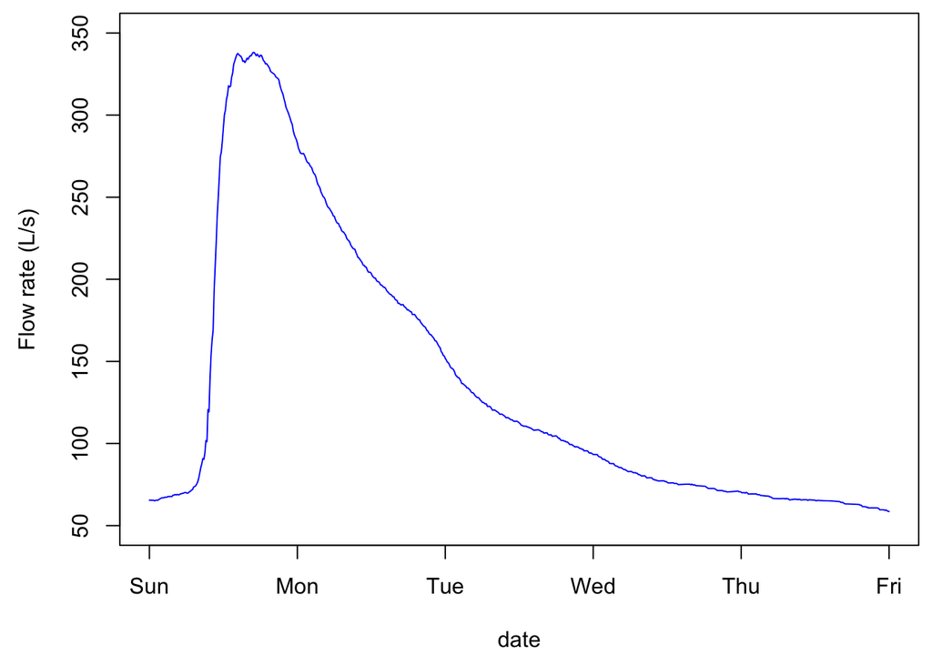

You can calculate things and incorporate them directly into your R markdown document. For example,

[output not shown]